# Assignment 7

Tejas Athni

11/30/2020

INTRO & BACKGROUND: In this report, I perform an analysis of greenhouse gas emissions, and more specifically, of visiting vehicle emissions and building emissions. I perform my visitor vehicle emissions analysis for the Clayton region (ZIP code: 94517), which resides in the San Ramon Valley of Contra Costa county and interestingly is known as the safest town in California. My definition of “visitor” vehicles focuses on external visitors; in other words, those who visit the Clayton census block groups (CBGs) from origin locations that reside outside of Clayton CBGs.

Unfortunately, I was unable to find available parcel and assessor datasets online for the Clayton region; thus, I have performed a building emissions analysis for the Outer Mission neighborhood of San Francisco (ZIP code: 94112) which is one of the south-most San Francisco regions that utilizes the PG&E utility for both residential and commercial, and both gas and electricity energy needs.

Furthermore, by focusing on Outer Mission for the building emissions analysis, I take advantage of the wealth of San Francisco parcel and assessor-recorder data easily available online. In this fashion, I believe my report gives an accurate insight into the vehicle AND building emissions for two separate aggregate areas, despite the inherent data limitations and lack of available online data to analyze building emissions in solely Clayton or solely Outer Mission.

One additional note about this analysis. In an attempt to standardize the ZIP codes for this analysis, I also tried to perform a vehicle emissions analysis for the Outer Mission region. However, since San Francisco is heavily and frequently visited in the summer months, the origin census block groups from the visitors were quite numerous. Due to this, the map_dfr function and my computer’s processing capabilities were unable to execute the Mapbox routing for the 1,000+ origin CBGs to the Outer Mission destination, with the jsonlite package also not properly complying. I also tried to run the Mapbox routing of the origin CBGs to Outer Mission with the origin CBGs broken up into separate “chunks” to reduce the processing demand, but this also would not execute due to my computer’s processing ability, or lack thereof. Thus, these are another justification for why this report includes a vehicle emissions analysis for Clayton (a quite rural area, with much fewer origin CBGs, around 430) but a building emissions analysis for the more-populous, more highly-visited Outer Mission.

LIBRARIES: I load in the necessary R packages needed to perform the analyses.

```r
library(tidyverse)
library(sf)
library(tigris)
library(leaflet)
library(censusapi)
library(readxl)
library(jsonlite)
library(mapboxapi)
library(dplyr)
library(tidycensus)

setwd("E:/SynologyDrive/Tejas_Server/! Stanford University/! Year 3 - Quarter 1/PoliSci 218X/Assignment 7")
Sys.setenv(CENSUS_KEY="0b20d8e27e52741cf293056779d3caf7e3793f0a")
census_api_key("0b20d8e27e52741cf293056779d3caf7e3793f0a")
readRenviron("~/.Renviron")
```

PART 1, VEHICLE EMISSIONS ANALYSIS: I first perform an analysis of vehicle emissions of all visitors entering CBGs contained within the Clayton ZIP code region from external CBGs during the month of June 2020. I utilize SafeGraph Neighborhood Patterns data for June 2020 to perform this analysis, aided by the underlying structure of US Census data.

```r
acs_vars_2018_5yr <-
  listCensusMetadata(
    name = "2018/acs/acs5",
    type = "variables"
  )

# june_patterns <- read_csv("neighborhood_patterns.gz")

ca_cbgs <- block_groups("CA", cb = T, progress_bar = F)

clayton_boundary <- zctas(starts_with = "94", cb = T, progress_bar = F) %>%
  filter(ZCTA5CE10 == "94517")


clayton_cbgs <-
  ca_cbgs %>%
  st_centroid() %>%
  .[clayton_boundary, ] %>%
  st_set_geometry(NULL) %>%
  left_join(ca_cbgs %>% select(GEOID)) %>%
  st_as_sf()

leaflet() %>%
  addMapboxTiles(
    style_id = "streets-v11",
    username = "mapbox"
  ) %>%
  addPolygons(
    data = clayton_cbgs,
    fill = F
  )



# clayton_patterns <-
#   june_patterns %>%
#   filter(area %in% clayton_cbgs$GEOID)
#
# saveRDS(clayton_patterns, "clayton_patterns.rds")

clayton_patterns <- readRDS("clayton_patterns.rds")



json <-
  clayton_patterns$device_home_areas[1] %>%
  fromJSON() %>%
  unlist() %>%
  as.data.frame() %>%
  rownames_to_column() %>%
  rename(
    origin_cbg = "rowname",
    device_count = "."
  )

head(json)


origin_cbgs <-
  1:nrow(clayton_patterns) %>%
  map_dfr(function(row){
    json <-
      clayton_patterns$device_home_areas[row] %>%
      fromJSON() %>%
      unlist() %>%
      as.data.frame() %>%
      rownames_to_column() %>%
      rename(
        origin_cbg = "rowname",
        device_count = "."
      ) %>%
      mutate(
        device_count = ifelse(
          device_count == 4,
          3,
          device_count
        )
      )
  })


origin_cbgs_merged <-
  origin_cbgs %>%
  group_by(origin_cbg) %>%
  summarize(
    device_count = max(device_count)
  )



home_panel_summary <- read_csv("home_panel_summary.gz")

ca_cbgs_pop <-
  counties("CA", cb = T, progress_bar = F) %>%
  pull(COUNTYFP) %>%
  map_dfr(function(x){
    getCensus(
      name = "acs/acs5",
      vintage = 2018,
      region = "block group:*",
      regionin = paste0("state:06+county:", x),
      vars = "B01001_001E"
    )
  }) %>%
  transmute(
    census_block_group =
      paste0(state,county,tract,block_group),
    pop = B01001_001E
  )

origin_cbgs_pop <-
  origin_cbgs_merged %>%
  left_join(
    ca_cbgs_pop,
    by = c("origin_cbg" = "census_block_group")
  )

sum(is.na(origin_cbgs_pop$pop))


origin_cbgs_normalized <-
  origin_cbgs_pop %>%
  filter(!is.na(pop)) %>%
  left_join(
    home_panel_summary %>%
      select(origin_cbg = census_block_group, number_devices_residing)
  ) %>%
  mutate(
    visits = (device_count * pop / number_devices_residing) %>% round()
  ) %>%
  left_join(ca_cbgs %>% select(origin_cbg = GEOID)) %>%
  st_as_sf()

origin_cbgs_normalized <- origin_cbgs_normalized[order(origin_cbgs_normalized$visits),]
origin_cbgs_normalized <- origin_cbgs_normalized[1:(nrow(origin_cbgs_normalized)-11),]

visits_pal <- colorNumeric(
  palette = "Reds",
  domain = origin_cbgs_normalized %>%
    arrange(desc(visits)) %>%
    pull(visits)
)

leaflet() %>%
  addMapboxTiles(
    style_id = "light-v9",
    username = "mapbox"
  ) %>%
  addPolygons(
    data = clayton_cbgs,
    fill = F
  ) %>%
  addPolygons(
    data = origin_cbgs_normalized,
    fillColor = ~visits_pal(visits),
    color = "red",
    weight = 1,
    fillOpacity = 0.75,
    label = ~visits
  )
```

[output not shown]

```r
#n <- dim(origin_cbgs_normalized)[1]

clayton_origin <-
  origin_cbgs_normalized %>%
  st_centroid() %>%
  st_coordinates()

clayton_destination <-
  clayton_boundary %>%
  st_centroid() %>%
  st_coordinates()

clayton_route <-
  1:nrow(clayton_origin) %>%
  map_dfr(function(x){
    mapboxapi::mb_directions(
      origin = clayton_origin[x, ],
      destination = clayton_destination,
      profile = "driving-traffic"
    )
  }) %>%
  st_as_sf()
```

```r
leaflet() %>%
  addMapboxTiles(
    style_id = "light-v9",
    username = "mapbox"
  ) %>%
  addPolylines(
    data = clayton_route
  )
```

[interactive chart not shown]

```r
travel_time_mode <-
  counties("CA", cb = T, progress_bar = F) %>%
  pull(COUNTYFP) %>%
  map_dfr(function(x){
    getCensus(
      name = "acs/acs5",
      vintage = 2018,
      region = "block group:*",
      regionin = paste0("state:06+county:", x),
      vars = "group(B08134)"
    )
  }) %>%
  mutate(
    cbg =
      paste0(state,county,tract,block_group)
  ) %>%
  filter(cbg %in% origin_cbgs_normalized$origin_cbg) %>%
  select(!c(GEO_ID,state,county,tract,block_group,NAME) & !ends_with(c("EA","MA","M"))) %>%
  pivot_longer(
    ends_with("E"),
    names_to = "variable",
    values_to = "estimate"
  ) %>%
  left_join(
    acs_vars_2018_5yr %>%
      select(name, label),
    by = c("variable" = "name")
  ) %>%
  select(-variable) %>%
  separate(
    label,
    into = c(NA, NA, "total", "mode", "carpool", "time"),
    sep = "!!"
  ) %>%
  mutate(
    mode = case_when(
      total %in% c(
        "Less than 10 minutes",
        "10 to 14 minutes",
        "15 to 19 minutes",
        "20 to 24 minutes",
        "25 to 29 minutes",
        "30 to 34 minutes",
        "35 to 44 minutes",
        "45 to 59 minutes",
        "60 or more minutes"
      ) ~ "Total",
      mode == "Drove alone" ~ mode,
      carpool %in% c(
        "In 2-person carpool",
        "In 3-or-more-person carpool"
      ) ~ carpool
    ),
    time = case_when(
      mode == "Total" ~ total,
      mode == "Drove alone" ~ carpool,
      mode == carpool ~ time
    )
  ) %>%
  filter(!is.na(time)) %>%
  select(-total, -carpool) %>%
  pivot_wider(
    names_from = mode,
    values_from = estimate
  ) %>%
  mutate(
    perc_veh1 = `Drove alone`/Total,
    perc_veh2 = `In 2-person carpool`/Total,
    perc_veh3 = `In 3-or-more-person carpool`/Total
  )



clayton_trips <-
  origin_cbgs_normalized %>%
  cbind(
    clayton_route %>%
      st_set_geometry(NULL)
  ) %>%
  mutate(
    time = case_when(
      duration < 10 ~ "Less than 10 minutes",
      duration < 15 ~ "10 to 14 minutes",
      duration < 20 ~ "15 to 19 minutes",
      duration < 25 ~ "20 to 24 minutes",
      duration < 30 ~ "25 to 29 minutes",
      duration < 35 ~ "30 to 34 minutes",
      duration < 45 ~ "35 to 44 minutes",
      duration < 60 ~ "45 to 59 minutes",
      TRUE ~ "60 or more minutes"
    )
  ) %>%
  left_join(
    travel_time_mode %>%
      select(
        origin_cbg = cbg,
        time,
        perc_veh1,
        perc_veh2,
        perc_veh3
      ),
    by = c("origin_cbg", "time")
  ) %>%
  mutate(
    vehicles =
      visits * perc_veh1 +
      visits * perc_veh2 / 2 +
      visits * perc_veh3 / 3,
    vmt = vehicles * distance * 2
  )



recorded_visits <- sum(clayton_trips$device_count)/
  sum(clayton_patterns$raw_device_counts)
recorded_visits
```

```
## [1] 0.2671516
```

```r
sum(clayton_trips$vmt, na.rm = T)/recorded_visits
```

```
## [1] 7787771
```

```r
emfac <-
  read_csv("EMFAC2017-EI-2011Class-BayAreaAQMD-2020-Summer-20201129111653_CLEANED.csv") %>%
  transmute(
    Category = `Category`,
    Fuel_Type = `Fuel_Type`,
    Percent_Trips = `Percent_Trips`,
    Percent_Miles = `Percent_Miles`,
    `gCO2_Running_Exhaust` = `gCO2_Running_Exhaust`,
    `gCO2_Start_Exhaust` = `gCO2_Start_Exhaust`
  )



clayton_trips_ghg <-
  emfac %>%
  mutate(
    trips = Percent_Trips * sum(clayton_trips$visits, na.rm = T),
    vmt = Percent_Miles * sum(clayton_trips$vmt, na.rm = T),
    ghg = vmt*gCO2_Running_Exhaust + trips*gCO2_Start_Exhaust*2
  )

sum(clayton_trips_ghg$ghg)*1e-6/recorded_visits
```

```
## [1] 2305.804
```

Since device counts of 2-4 are masked as “4,” I have converted these values to “3” to better represent the average between 2 to 4. My calculated number of recorded visits was roughly 0.27, which is a significant underestimation of devices. Fortunately, the normalization of trips divided by visits remedies the potential for under-counting the true amount of trips.

Another caveat is that the EMFAC dataset online aggregated N2O and CH4 values in the downloadable CSV file, when in reality I want these values to be parsed out. Thus, I scraped the EMFAC table from Section 7.1 in the textbook, created a new csv, and loaded in Derek’s pre-calculated values. This yields a more accurate and reasonable aggregated Clayton emissions because we are not accounting for CH4 and N2O.

PART 1, RESULTS & DISCUSSION: There were roughly 7.7 million vehicle miles traveled in June 2020 alone by visitors to the Clayton ZIP code region. Utilizing the California Air Resources Board (CARB)‘s Emissions Factors (EMFAC) model, I found that roughly 2,300 metric tonnes (adjusted for unrecorded visits) were emitted during visits to Clayton in June 2020. Assuming that the average American emits 10 tonnes of CO2 equivalents annually, this is about 230 Americans’ yearly emissions worth in just one month’s worth of travel to one particular ZIP code in one particular rural area of Contra Costa (i.e., Clayton)!

PART 2, BUILDING EMISSIONS ANALYSIS: Next, I perform an analysis of residential and commercial, electricity and gas usage-associated building emissions in the Outer Mission neighborhood of San Francisco: one of the south-most San Francisco neighborhoods that utilizes PG&E for their energy needs. I utilize PG&E data at the ZIP code level filtered for the month of June 2020, to quasi-match the above SafeGraph Neighborhood Patterns data in the vehicle emissions analysis. I also take advantage of the San Francisco parcel and assessor-recorder data to perform this analysis.

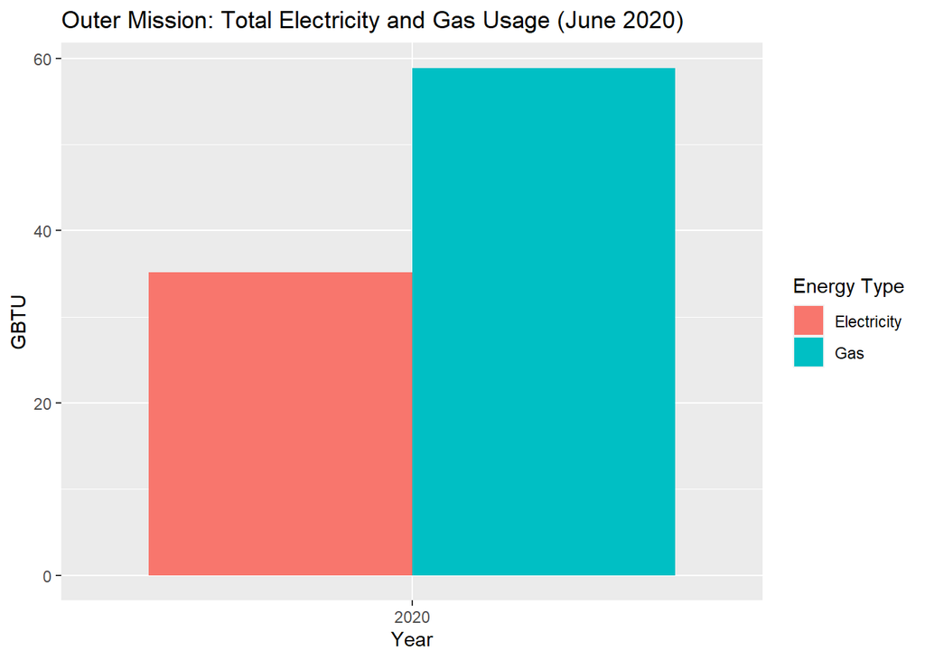

```r
emissions_factor <- 198

pge_data <-
  c("Electric","Gas") %>%
    map_dfr(function(type){
      filename <-
        paste0(
          "PGE_2020_Q2_",
          type,
          "UsageByZip.csv"
        )

      temp <- read_csv(filename)

      temp <-
        temp %>%
        rename_all(toupper) %>%
        mutate(
          TOTALKBTU = ifelse(
            substr(CUSTOMERCLASS,1,1) == "E",
            TOTALKWH * 3.412,
            TOTALTHM * 99.976
          ),
          TOTALTCO2E = ifelse(
            substr(CUSTOMERCLASS,1,1) == "E",
            TOTALKWH/1000 * emissions_factor * 0.000453592,
            TOTALTHM * 0.00531
          )
        ) %>%
        select(
          ZIPCODE,
          YEAR,
          MONTH,
          CUSTOMERCLASS,
          TOTALKBTU,
          TOTALTCO2E,
          TOTALCUSTOMERS
        )
    })


us_zips <-
  zctas(cb = T, progress_bar = F)

ca_zips <-
  zctas(cb = T, state = "CA", progress_bar = F)

outer_mission_zips <-
  us_zips %>%
  filter(ZCTA5CE10 == "94112") %>%
  st_as_sf()




outer_mission_pge_data <-
  pge_data %>%
  filter(ZIPCODE %in% outer_mission_zips$ZCTA5CE10) %>%
  filter(MONTH == "6") %>%
  filter(CUSTOMERCLASS %in% c(
    "Elec- Commercial",
    "Elec- Residential",
    "Gas- Commercial",
    "Gas- Residential"
  )) %>%
  mutate(
    ENERGYTYPE = substr(CUSTOMERCLASS,1,1)
  ) %>%
  group_by(ENERGYTYPE, YEAR) %>%
  summarize(
    TOTALKBTU = sum(TOTALKBTU, na.rm=T),
    TOTALTCO2E = sum(TOTALTCO2E, na.rm=T),
    TOTALCUSTOMERS = mean(TOTALCUSTOMERS, na.rm=T)
  ) %>%
  group_by(ENERGYTYPE, YEAR) %>%
  summarize_at(
    vars(TOTALKBTU,TOTALTCO2E,TOTALCUSTOMERS),
    sum,
    na.rm=T
  )



ggplot(
  outer_mission_pge_data,
  aes(
    x = as.factor(YEAR),
    y = TOTALKBTU/1000000
  )
) +
  geom_bar(stat = "identity", aes(fill = ENERGYTYPE), position = "dodge") +
  labs(x = "Year", y = "GBTU", title = "Outer Mission: Total Electricity and Gas Usage (June 2020)") +
  scale_fill_discrete(name="Energy Type",labels = c("Electricity","Gas"))
```

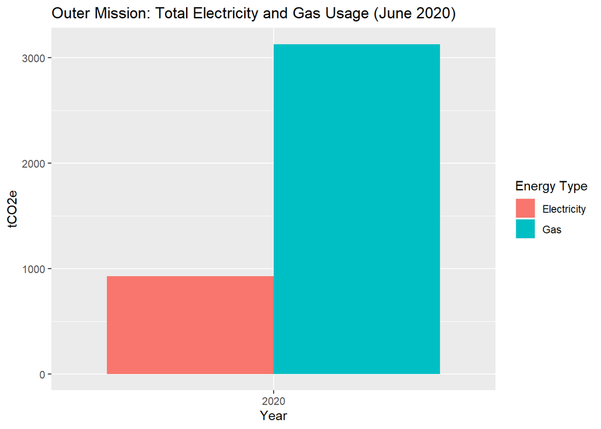

```r
ggplot(
  outer_mission_pge_data,
  aes(
    x = as.factor(YEAR),
    y = TOTALTCO2E
  )
) +
  geom_bar(stat = "identity", aes(fill = ENERGYTYPE), position = "dodge") +
  labs(x = "Year", y = "tCO2e", title = "Outer Mission: Total Electricity and Gas Usage (June 2020)") +
  scale_fill_discrete(name="Energy Type",labels = c("Electricity","Gas"))
```

```r
temp <- tempfile()
download.file("https://sfassessor.org/sites/default/files/uploaded/2020.7.10_SF_ASR_Secured_Roll_Data_2019-2020.xlsx",destfile = temp, mode = "wb")
sf_secured_20 <- read_excel(temp, sheet = "Roll Data 2019-2020")
saveRDS(sf_secured_20, "sf_secured_20.rds")
unlink(temp)


sf_parcels_shape <-
 st_read("https://data.sfgov.org/api/geospatial/acdm-wktn?method=export&format=GeoJSON") %>%
 select(
   apn = blklot
 ) %>%
  st_transform(st_crs(ca_zips))
```

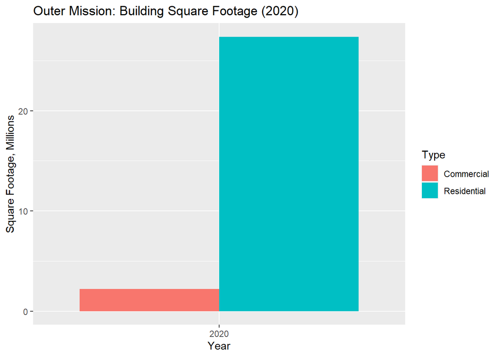

```r
sf_secured_summary <- NULL

data <-
  readRDS("sf_secured_20.rds") %>%
  mutate(
    apn = RP1PRCLID %>%
      str_replace(" ","")
  ) %>%
  left_join(
    sf_parcels_shape
  ) %>%
  st_as_sf() %>%
  st_centroid() %>%
  st_join(
    ca_zips %>%
      select(ZIPCODE = GEOID10)
  ) %>%
  st_set_geometry(NULL) %>%
  mutate(
    TYPE = case_when(
      RP1CLACDE %in% c("A","A15","A5","CO","COS","D","DA","DA15","DA5","DBM","DCON","DD","DD15","DD5","DF","F","F15","F5","FA","FA15","FA5","LZ","LZBM","N2","RH","TH","THBM","TI15","TIA","TIC","TIC5","TIF","TS","TSF","TSU","XV","Z","ZBM") ~ "Residential",
      RP1CLACDE %in% c("AC","F2","FS","FS15","FS5","MIX","OA","OA15","OA5") ~ "Mixed",
      !RP1CLACDE %in% c("I","IDC","IW","IX","IZ") ~ "Commercial"
    )
  ) %>%
  filter(!is.na(TYPE)) %>%
  filter(ZIPCODE == "94112")



data <- data %>%
  group_by(ZIPCODE, TYPE) %>%
  summarize(SQFT = sum(SQFT, na.rm = T)) %>%
  pivot_wider(
    names_from = TYPE,
    values_from = SQFT
  ) %>%
  mutate(
    Commercial = Commercial + Mixed/2,
    Residential = Residential + Mixed/2
  ) %>%
  select(-Mixed) %>%
  filter(!is.na(Commercial) & !is.na(Residential)) %>%
  pivot_longer(
    -ZIPCODE,
    names_to = "TYPE",
    values_to = "SQFT"
  )


sf_secured_summary <- data


sf_secured_summary %>%
  group_by(TYPE) %>%
  summarize(SQFT = sum(SQFT)) %>%
  ggplot(
    aes(
      x = as.factor("2020"),
      y = SQFT/1000000
    )
  ) +
  geom_bar(stat = "identity", aes(fill = TYPE), position = "dodge") +
  labs(x = "Year", y = "Square Footage, Millions", title = "Outer Mission: Building Square Footage (2020)") +
  scale_fill_discrete(name="Type")
```

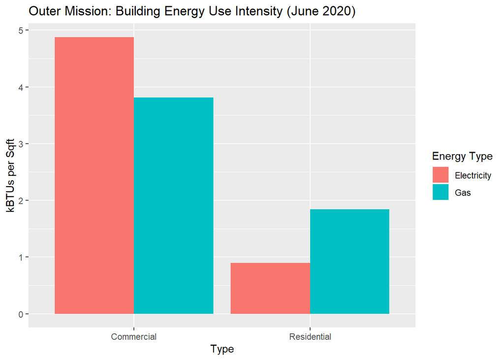

```r
sf_pge_sqft <-
  pge_data %>%
  filter(ZIPCODE %in% sf_secured_summary$ZIPCODE) %>%
  filter(MONTH == "6") %>%
  filter(CUSTOMERCLASS %in% c(
    "Elec- Commercial",
    "Elec- Residential",
    "Gas- Commercial",
    "Gas- Residential"
  )) %>%
  mutate(
    ZIPCODE = ZIPCODE %>% as.character(),
    ENERGYTYPE = substr(CUSTOMERCLASS,1,1),
    TYPE = substr(CUSTOMERCLASS,6,nchar(CUSTOMERCLASS)) %>% str_trim()
  ) %>%
  group_by(ZIPCODE, ENERGYTYPE, TYPE) %>%
  summarize(
    TOTALKBTU = sum(TOTALKBTU, na.rm=T)
  ) %>%
  left_join(
    sf_secured_summary,
    by = c("ZIPCODE","TYPE")
  ) %>%
  filter(!is.na(SQFT)) %>%
  mutate(
    KBTU_SQFT = TOTALKBTU/SQFT
  )

sf_pge_sqft[sf_pge_sqft == "E"] <- "Electricity"
sf_pge_sqft[sf_pge_sqft == "G"] <- "Gas"

sf_pge_sqft <- sf_pge_sqft %>%
  group_by(ZIPCODE, ENERGYTYPE, TYPE) %>%
  summarize(
    TOTALKBTU = sum(TOTALKBTU),
    SQFT = sum(SQFT)
  ) %>%
  mutate(
    KBTU_SQFT = TOTALKBTU/SQFT
  )



ggplot(
  sf_pge_sqft,
  aes(
    x = TYPE,
    y = KBTU_SQFT
  )
) +
  geom_bar(stat = "identity", aes(fill = ENERGYTYPE), position = "dodge") +
  labs(x = "Type", y = "kBTUs per Sqft", title = "Outer Mission: Building Energy Use Intensity (June 2020)") +
  scale_fill_discrete(name="Energy Type",labels = c("Electricity","Gas"))
```

PART 2, ASSUMPTIONS: I have estimated the emissions factor for 2020 to be the value 198 based on a 4 pounds of CO2 per MWh decline each year (estimated from 2017-2018), and forward-projected that same trend from 2017 onwards. Industrial sources of emissions will be masked due to the CPUC 15-15 energy customer anonymity rule in the public PG&E dataset.

Commercial electricity was 4.9 kBTU/sqft, while commercial gas was slightly less at 3.8 kBTU/sqft. Residential electricity was 0.89 kBTU/sqft, while residential gas was 1.84 kBTU/sqft. Analyzing these above metrics, it seems that the lowest building energy use intensity in June 2020 in Outer Mission can be attributed to residential electricity, likely due to a combination of California residents nowadays having highly energy-efficient electric appliances or LED-based lighting. Meanwhile, the highest building energy use intensity was attributed to commercial electricity usage, which concords with the fact that industries often have less energy efficiency. Furthermore, if we analyze the specific industries that are located in Outer Mission – many construction, solar, brewing, and engineering companies – these tend to utilize lots of electricity on a daily basis for operations. Holistically, residential gas AND electricity usage was lower than commercial, with electricity dominating gas use intensity in the commercial setting while gas dominated electricity use intensity in the residential setting.

Furthermore, the gap between commercial and residential electricity use intensity (which is the largest divide depicted in the graph) could be attributed to widely-varible and unique plug loads that differ from residential to commercial sector setting. In contrast, gas use intensities are more similar, and garner a somewhat similar demand per square footage regardless of the commercial or residential setting.

```r
sf_pge_sqft_20 <-
  sf_pge_sqft %>%
  left_join(outer_mission_zips %>% select(ZIPCODE = GEOID10)) %>%
  st_as_sf()

pal1 <- colorNumeric(
  palette = "Reds",
  domain = sf_pge_sqft_20 %>%
    filter(ENERGYTYPE == "Electricity", TYPE == "Commercial") %>%
    pull(TOTALKBTU)
)

pal2 <- colorNumeric(
  palette = "Blues",
  domain = sf_pge_sqft_20 %>%
    filter(ENERGYTYPE == "Electricity", TYPE == "Commercial") %>%
    pull(SQFT)
)

pal3 <- colorNumeric(
  palette = "Purples",
  domain = sf_pge_sqft_20 %>%
    filter(ENERGYTYPE == "Electricity", TYPE == "Commercial") %>%
    pull(KBTU_SQFT)
)

sf_pge_sqft_20 %>%
  filter(ENERGYTYPE == "Electricity", TYPE == "Commercial") %>%
  leaflet() %>%
  addMapboxTiles(
    style_id = "streets-v11",
    username = "mapbox"
  ) %>%
  addPolygons(
    fillColor = ~pal1(TOTALKBTU),
    fillOpacity = 0.5,
    stroke = F,
    label = ~TOTALKBTU %>% signif(2),
    group = "KBTU"
  ) %>%
  addPolygons(
    fillColor = ~pal2(SQFT),
    fillOpacity = 0.5,
    stroke = F,
    label = ~SQFT %>% signif(2),
    group = "SQFT"
  ) %>%
  addPolygons(
    fillColor = ~pal3(KBTU_SQFT),
    fillOpacity = 0.5,
    stroke = F,
    label = ~KBTU_SQFT %>% signif(2),
    group = "KBTU/SQFT"
  ) %>%
  addLayersControl(
    baseGroups = c("KBTU","SQFT","KBTU/SQFT"),
    options = layersControlOptions(collapsed = FALSE)
  )
```

[interactive chart not shown]

Above: Commercial Electricity

```r
pal1 <- colorNumeric(
  palette = "Reds",
  domain = sf_pge_sqft_20 %>%
    filter(ENERGYTYPE == "Gas", TYPE == "Commercial") %>%
    pull(TOTALKBTU)
)

pal2 <- colorNumeric(
  palette = "Blues",
  domain = sf_pge_sqft_20 %>%
    filter(ENERGYTYPE == "Gas", TYPE == "Commercial") %>%
    pull(SQFT)
)

pal3 <- colorNumeric(
  palette = "Purples",
  domain = sf_pge_sqft_20 %>%
    filter(ENERGYTYPE == "Gas", TYPE == "Commercial") %>%
    pull(KBTU_SQFT)
)

sf_pge_sqft_20 %>%
  filter(ENERGYTYPE == "Gas", TYPE == "Commercial") %>%
  leaflet() %>%
  addMapboxTiles(
    style_id = "streets-v11",
    username = "mapbox"
  ) %>%
  addPolygons(
    fillColor = ~pal1(TOTALKBTU),
    fillOpacity = 0.5,
    stroke = F,
    label = ~TOTALKBTU %>% signif(2),
    group = "KBTU"
  ) %>%
  addPolygons(
    fillColor = ~pal2(SQFT),
    fillOpacity = 0.5,
    stroke = F,
    label = ~SQFT %>% signif(2),
    group = "SQFT"
  ) %>%
  addPolygons(
    fillColor = ~pal3(KBTU_SQFT),
    fillOpacity = 0.5,
    stroke = F,
    label = ~KBTU_SQFT %>% signif(2),
    group = "KBTU/SQFT"
  ) %>%
  addLayersControl(
    baseGroups = c("KBTU","SQFT","KBTU/SQFT"),
    options = layersControlOptions(collapsed = FALSE)
  )
```

[interactive chart not shown]

Above: Commercial Gas

```r
pal1 <- colorNumeric(
  palette = "Reds",
  domain = sf_pge_sqft_20 %>%
    filter(ENERGYTYPE == "Electricity", TYPE == "Residential") %>%
    pull(TOTALKBTU)
)

pal2 <- colorNumeric(
  palette = "Blues",
  domain = sf_pge_sqft_20 %>%
    filter(ENERGYTYPE == "Electricity", TYPE == "Residential") %>%
    pull(SQFT)
)

pal3 <- colorNumeric(
  palette = "Purples",
  domain = sf_pge_sqft_20 %>%
    filter(ENERGYTYPE == "Electricity", TYPE == "Residential") %>%
    pull(KBTU_SQFT)
)

sf_pge_sqft_20 %>%
  filter(ENERGYTYPE == "Electricity", TYPE == "Residential") %>%
  leaflet() %>%
  addMapboxTiles(
    style_id = "streets-v11",
    username = "mapbox"
  ) %>%
  addPolygons(
    fillColor = ~pal1(TOTALKBTU),
    fillOpacity = 0.5,
    stroke = F,
    label = ~TOTALKBTU %>% signif(2),
    group = "KBTU"
  ) %>%
  addPolygons(
    fillColor = ~pal2(SQFT),
    fillOpacity = 0.5,
    stroke = F,
    label = ~SQFT %>% signif(2),
    group = "SQFT"
  ) %>%
  addPolygons(
    fillColor = ~pal3(KBTU_SQFT),
    fillOpacity = 0.5,
    stroke = F,
    label = ~KBTU_SQFT %>% signif(2),
    group = "KBTU/SQFT"
  ) %>%
  addLayersControl(
    baseGroups = c("KBTU","SQFT","KBTU/SQFT"),
    options = layersControlOptions(collapsed = FALSE)
  )
```

[interactive chart not shown]

Above: Residential Electricity

```r
pal1 <- colorNumeric(
  palette = "Reds",
  domain = sf_pge_sqft_20 %>%
    filter(ENERGYTYPE == "Gas", TYPE == "Residential") %>%
    pull(TOTALKBTU)
)

pal2 <- colorNumeric(
  palette = "Blues",
  domain = sf_pge_sqft_20 %>%
    filter(ENERGYTYPE == "Gas", TYPE == "Residential") %>%
    pull(SQFT)
)

pal3 <- colorNumeric(
  palette = "Purples",
  domain = sf_pge_sqft_20 %>%
    filter(ENERGYTYPE == "Gas", TYPE == "Residential") %>%
    pull(KBTU_SQFT)
)

sf_pge_sqft_20 %>%
  filter(ENERGYTYPE == "Gas", TYPE == "Residential") %>%
  leaflet() %>%
  addMapboxTiles(
    style_id = "streets-v11",
    username = "mapbox"
  ) %>%
  addPolygons(
    fillColor = ~pal1(TOTALKBTU),
    fillOpacity = 0.5,
    stroke = F,
    label = ~TOTALKBTU %>% signif(2),
    group = "KBTU"
  ) %>%
  addPolygons(
    fillColor = ~pal2(SQFT),
    fillOpacity = 0.5,
    stroke = F,
    label = ~SQFT %>% signif(2),
    group = "SQFT"
  ) %>%
  addPolygons(
    fillColor = ~pal3(KBTU_SQFT),
    fillOpacity = 0.5,
    stroke = F,
    label = ~KBTU_SQFT %>% signif(2),
    group = "KBTU/SQFT"
  ) %>%
  addLayersControl(
    baseGroups = c("KBTU","SQFT","KBTU/SQFT"),
    options = layersControlOptions(collapsed = FALSE)
  )
```

[interactive chart not shown]

Above: Residential Gas

PART 2, RESULTS & DISCUSSION (CONTINUED): In the 4 map-graphs displayed above, the trends in kBTU, square footage, and the metric of building energy use intensity (kBTU/sqft) are displayed geospatially for each type of setting (i.e., residential or commercial) and each type of energy use (i.e., electricity or gas). The graphs depict values for Outer Mission, CA in June 2020.